# Project 2 - THANH DUY TANG 22803018

```r
print(tablehostrespone[,2]/(tablehostrespone[,1]+tablehostrespone[,2]))
```

```
a few days or more                N/A       within a day within a few hours     within an hour
        0.04651163         0.10377358         0.22899160         0.34004739         0.48080439
```

We can see that for those who responsed within an hour, there are 48% that they can be superhost, and those who responsed within a few hours, the probability that they can be superhost is 34% and so on. This way is good for those variables having less categorical values.

```r
mkPredC <- function(outCol,varCol,appCol) {
pPos <- sum(outCol==pos)/length(outCol)
naTab <- table(as.factor(outCol[is.na(varCol)]))
pPosWna <- (naTab/sum(naTab))[pos]
vTab <- table(as.factor(outCol),varCol)
pPosWv <- (vTab[pos,]+1.0e-3*pPos)/(colSums(vTab)+1.0e-3)
pred <- pPosWv[appCol]
pred[is.na(appCol)] <- pPosWna
pred[is.na(pred)] <- pPos
pred
}
```

```r
for(v in catVars) {
  pi <- paste('pred',v,sep='')
  dTrain[,pi] <- mkPredC(dTrain[,outcome],
                         dTrain[,v],dTrain[,v])
  dCal[,pi] <- mkPredC(dTrain[,outcome],
                       dTrain[,v],dCal[,v])
  dTest[,pi] <- mkPredC(dTrain[,outcome],
                        dTrain[,v],dTest[,v])
}
```

```r
library('ROCR')
calcAUC <- function(predcol,outcol) {
  perf <- performance(prediction(predcol,outcol==pos),'auc')
  as.numeric(perf@y.values)
}
```

These categorical variables have not good aucTrain, so I set aucTrain >= 0.5 to see the aucTrain and calibrationAUC of categorical variables. As I can see, trainAUC and calibrationAUC work very well in both train dataset and calibration dataset, which are 0.624 and 0.622 respectively.

```r
for(v in catVars) {
  pi <- paste('pred',v,sep='')
  aucTrain <- calcAUC(dTrain[,pi],dTrain[,outcome])
  if(aucTrain>= 0.5) {
    aucCal <- calcAUC(dCal[,pi],dCal[,outcome])
    print(sprintf(
      "%s, trainAUC: %4.3f calibrationAUC: %4.3f",
      pi, aucTrain, aucCal))
  }
}
```

```
[1] "predhost_response_time, trainAUC: 0.624 calibrationAUC: 0.622"
[1] "predproperty_type, trainAUC: 0.561 calibrationAUC: 0.558"
[1] "predroom_type, trainAUC: 0.518 calibrationAUC: 0.507"
[1] "predcancellation_policy, trainAUC: 0.545 calibrationAUC: 0.529"
[1] "predbed_type, trainAUC: 0.501 calibrationAUC: 0.502"
```

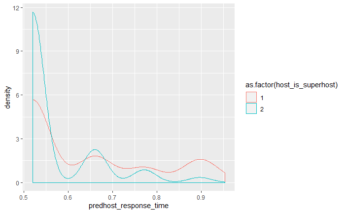

```r
library(ggplot2)
ggplot(data=dCal) +
geom_density(aes(x= predhost_response_time, color=as.factor(host_is_superhost)))
```

```r
mkPredN <- function(outCol,varCol,appCol) {
cuts <- unique(as.numeric(
quantile(varCol, probs=seq(0, 1, 0.1),na.rm=T)))
varC <- cut(varCol,cuts)
appC <- cut(appCol,cuts)
mkPredC(outCol,varC,appC)
}
```

```r
for(v in numericVars) {
pi<-paste('pred',v,sep='')
dTrain[,pi]<-mkPredN(dTrain[,outcome],dTrain[,v],dTrain[,v])
dTest[,pi]<-mkPredN(dTrain[,outcome],dTrain[,v],dTest[,v])
dCal[,pi]<-mkPredN(dTrain[,outcome],dTrain[,v],dCal[,v])
aucTrain<-calcAUC(dTrain[,pi],dTrain[,outcome])
if(aucTrain>=0.7) {
aucCal<-calcAUC(dCal[,pi],dCal[,outcome])
print(sprintf(
"%s, trainAUC: %4.3f calibrationAUC: %4.3f",
pi,aucTrain,aucCal))
}
}
```

```
[1] "prednumber_of_reviews, trainAUC: 0.705 calibrationAUC: 0.723"
[1] "predreview_scores_rating, trainAUC: 0.755 calibrationAUC: 0.762"
```

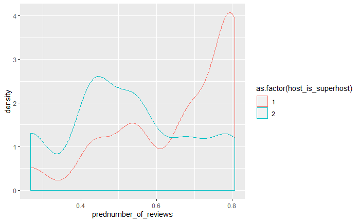

```r
library(ggplot2)
ggplot(data=dCal) +
geom_density(aes(x= prednumber_of_reviews, color=as.factor(host_is_superhost)))
```

100 - FOLDS CROSS-VALIDATION

```r
var <- 'host_response_time'
aucs <- rep(0,100)

for(rep in 1:length(aucs)) {
  useForCalRep<-rbinom(n=nrow(dTrainAll),size=1,prob=0.1)>0
  predRep<-mkPredC(dTrainAll[!useForCalRep,outcome],
                   dTrainAll[!useForCalRep,var],
                   dTrainAll[useForCalRep,var])
  aucs[rep]<-calcAUC(predRep,dTrainAll[useForCalRep,outcome])
}
mean(aucs)
```

```
[1] 0.6263705
```

```r
sd(aucs)
```

```
[1] 0.01403192
```

```r
var <- 'number_of_reviews'
aucs <- rep(0,100)

for(rep in 1:length(aucs)) {
  useForCalRep<-rbinom(n=nrow(dTrainAll),size=1,prob=0.1)>0
  predRep<-mkPredC(dTrainAll[!useForCalRep,outcome],
                   dTrainAll[!useForCalRep,var],
                   dTrainAll[useForCalRep,var])
  aucs[rep]<-calcAUC(predRep,dTrainAll[useForCalRep,outcome])
}
mean(aucs)
```

```
[1] 0.6682864
```

```r
sd(aucs)
```

```
[1] 0.04183837
```

```r
var <- 'review_scores_rating'
aucs <- rep(0,100)

for(rep in 1:length(aucs)) {
  useForCalRep<-rbinom(n=nrow(dTrainAll),size=1,prob=0.1)>0
  predRep<-mkPredC(dTrainAll[!useForCalRep,outcome],
                   dTrainAll[!useForCalRep,var],
                   dTrainAll[useForCalRep,var])
  aucs[rep]<-calcAUC(predRep,dTrainAll[useForCalRep,outcome])
}
mean(aucs)
```

```
[1] 0.500657
```

```r
sd(aucs)
```

```
[1] 0.0008502008
```

MULTIPLE VARIABLES

```r
logLikelyhood <- function(outCol,predCol) {
  sum(ifelse(outCol==pos,log(predCol),log(1-predCol)))
}
```

This is the step to compute the base rate of saturation model. And the best deviance I can get is also the baseRateCheck which is -448.3728.

```r
baseRateCheck <-
  logLikelyhood(
    dCal[,outcome],
    sum(dCal[,outcome]==pos)/length(dCal[,outcome])
  )
baseRateCheck
```

```
[1] -448.3728
```

This step will explain about the degree of uncertainty on the model. This also ranked the categorical varibles based on the calibrationScore.

```r
selVars <- c()
minStep <- 5

for(v in catVars) {
  pi <- paste('pred',v,sep='')
  liCheck <- 2*((logLikelyhood(dCal[,outcome],dCal[,pi])
                 - baseRateCheck))
  if(liCheck>minStep) {
    print(sprintf("%s, calibrationScore: %g",pi,liCheck))
    selVars <- c(selVars,pi)
  }
}
```

```
[1] "predhost_response_time, calibrationScore: 51.226"
[1] "predproperty_type, calibrationScore: 14.6932"
[1] "predcancellation_policy, calibrationScore: 5.12188"
```

I did the same step in numeric variables as the categorical variables above. As I can see, the values of three numeric variables are higher than categorical variables, which means I can select another threshold. After this, we can use selVars in this step to process next part Decision Tree

```r
for(v in numericVars) {
pi <- paste('pred',v,sep='')
liCheck <- 2*((logLikelyhood(dCal[,outcome],dCal[,pi])
- baseRateCheck) - 1)
if(liCheck>=minStep) {
print(sprintf("%s, calibrationScore: %g", pi,liCheck))
selVars <- c(selVars,pi)
}
}
```

```
[1] "predhost_response_rate, calibrationScore: 56.8333"
[1] "prednumber_of_reviews, calibrationScore: 95.4394"
[1] "predreview_scores_rating, calibrationScore: 148.865"
```

DECISION TREE